# Spotify

```r
install.packages("tidyverse", repos = "http://cran.us.r-project.org")
library("tidyverse")
```

### METHODOLOGY

The data used here is a list of the top 200 most streamed songs per day on Spotify from January 1, 2017 to January 9, 2018. It has 74,200 observations and 8 variables: song position, song name, performing artist, number of streams, and region. Unless otherwise specified, the region analyzed is the U.S.

Note: some tracks appear twice, e.g. Big Sean - “Pull Up N Wreck (& Metro Boomin)” v Big Sean - “Pull Up N Wreck (With Metro Boomin)”.

### DATA OVERVIEW

A good starting point for any data analysis is to look at the data’s distribution.

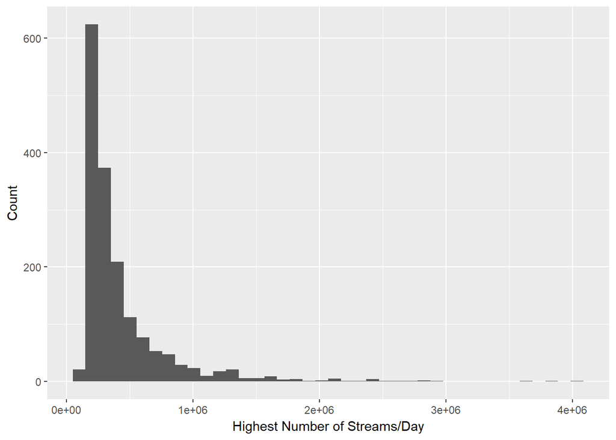

The distribution of artists reaching the top 200 is just as skewed: the top 20 most streamed artists make up 37.04% of the top 200.

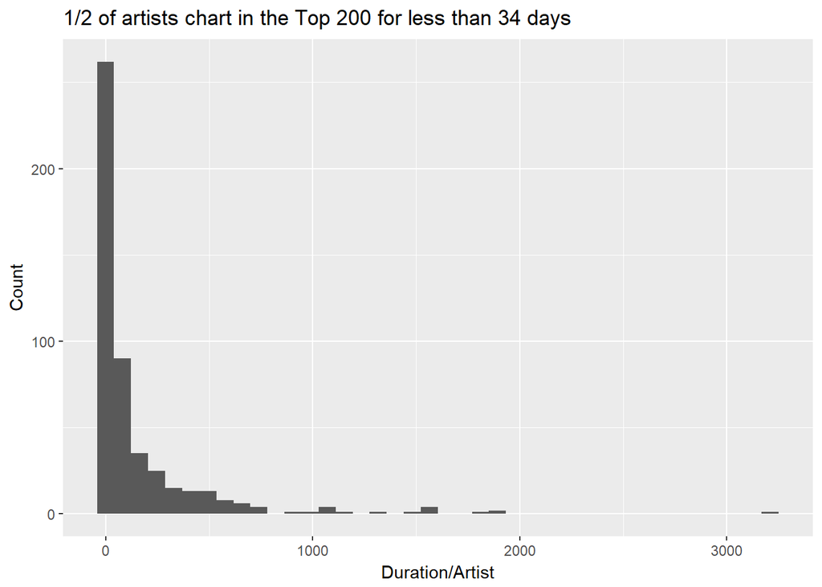

Half of artists have a song charted in the top 200 for less than 34 days per year; similarly, half of songs last less than 8 days in the top 200.

Surely, this distribution isn’t set in stone:

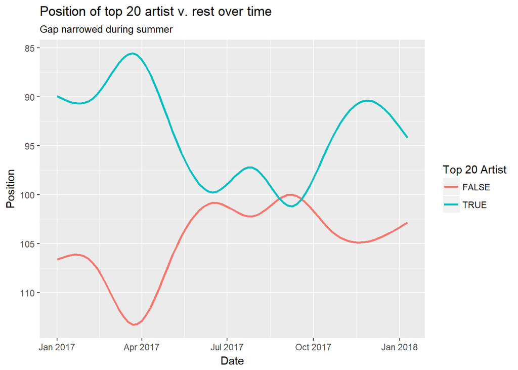

Another big equalizer seems to be the holiday season.

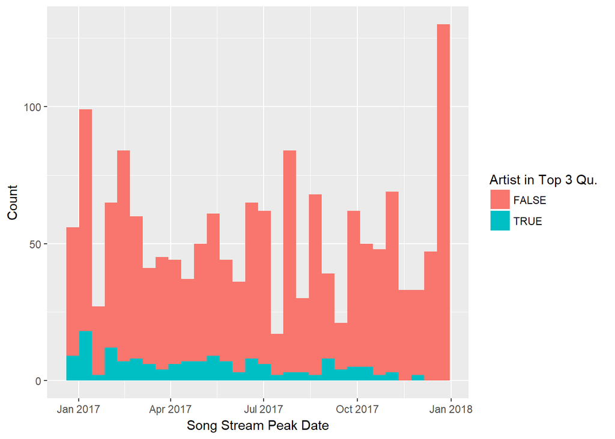

### SONG TRAJECTORIES

#### SEASONAL EFFECTS

We can plot the average number of streams per day to further explore the idea of seasonality in music consumption. Statistical outliers (e.g. Kendrick Lamar’s “HUMBLE.”) were removed to avoid distorting the graph.

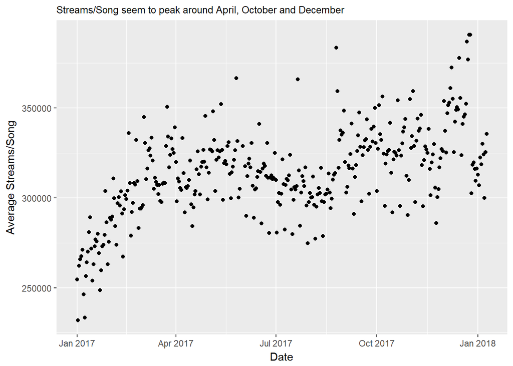

It seems that there are seasonal effects, most visible around the end of year.

#### NO. 1 HITS

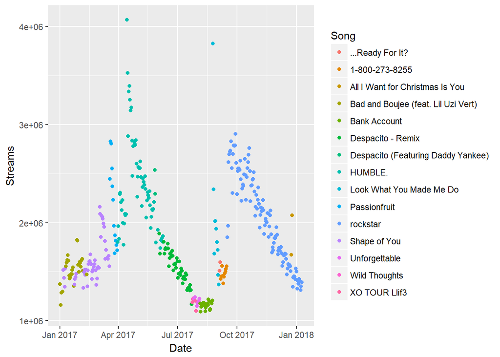

The first thing to note about the graph is that same seasonal patterns found above for average streams/song is exacerbated in the streams of #1 hits. (Recall that outliers were removed from the previous graph).However, the end-of-year peak found for *all* Top 200 songs isn’t visible here, which corroborates our theory that the end-of-year ‘equalizes’ the streaming distribution between ‘superstars’ and the rest.

```
## # A tibble: 2 x 4
## # Groups:   Artist [?]
##   Artist       Track.Name                      min_date   max_date
##   <fct>        <fct>                           <date>     <date>
## 1 Mariah Carey All I Want for Christmas Is You 2017-12-24 2017-12-25
## 2 Post Malone  rockstar                        2017-12-01 2018-01-01
```

Mariah Carey’s “All I Want for Christmas…” is an obvious example of a highly seasonal song. As such, it overtakes the most popular song of the moment (Post Malone’s “rockstar”) just in time for the holidays, and drops out immediately afterwards.

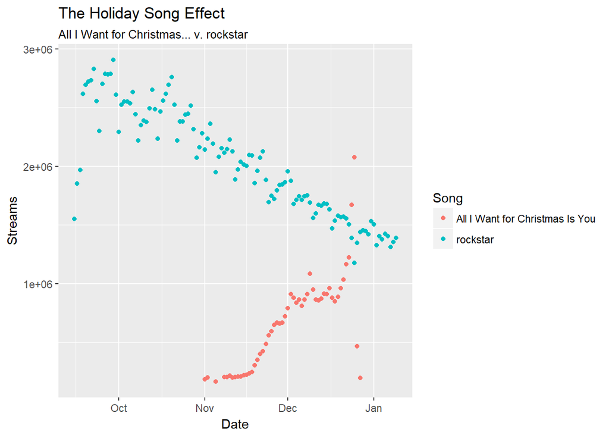

Another point of note is that it is therefore possible to become a number 1 with a relatively low number of streams.

```
## # A tibble: 3 x 6
## # Groups:   Artist [3]
##   Artist         Track.Name    min_stream max_stream av_stream duration
##   <fct>          <fct>              <dbl>      <dbl>     <dbl> <time>
## 1 21 Savage      Bank Account     1092379    1216555   1159450 19
## 2 Lil Uzi Vert   XO TOUR Llif3    1097761    1222816   1178128 6
## 3 French Montana Unforgettable    1147906    1238665   1199043 8
```

Thus, 21 Savage - “Bank Account” become number 1 between August 5 and August 24, 2017 with only an average of 1,159,450 streams per day.

#### SHORT V. LONG-LASTING HITS

“Bank Account” may have had a low streaming average for a #1 hit, but it did retain its position for 19 days (albeit during a “low season” for streams). The songs below were number 1 for less than two days:

```
## # A tibble: 4 x 6
## # Groups:   Artist [4]
##   Artist       Track.Name         min_stream max_stream av_stream duration
##   <fct>        <fct>                   <dbl>      <dbl>     <dbl> <time>
## 1 DJ Khaled    Wild Thoughts         1230131    1230131   1230131 0
## 2 Luis Fonsi   Despacito (Featur~    2293547    2537245   2415396 1
## 3 Mariah Carey All I Want for Ch~    1670708    2075827   1873268 1
## 4 Taylor Swift ...Ready For It?      1510148    1597419   1553784 1
```

When plotting two number one songs with vastly different durations, we can see that their trajectory differs over time quite a bit too.

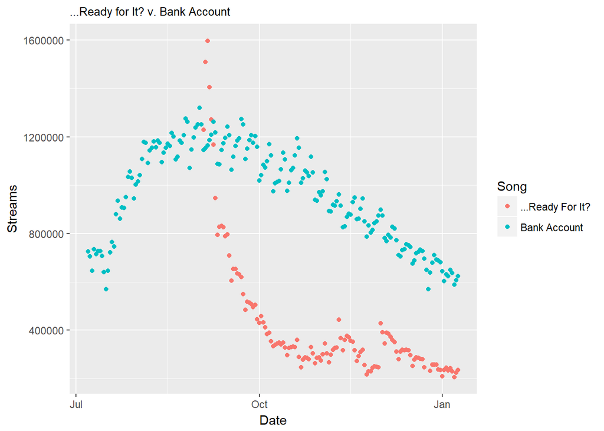

“…Ready For It?” loses its top 1 position almost immediately. Though “Bank Account” also decreases, the slope of its curve is much gentler.

One way to (indirectly) measure this slope is to calculate the *standard deviation* of a song’s position over time.

```
## # A tibble: 2 x 3
## # Groups:   Artist [?]
##   Artist       Track.Name       volatility
##   <fct>        <fct>                 <dbl>
## 1 21 Savage    Bank Account           6.44
## 2 Taylor Swift ...Ready For It?      35.9
```

As we might’ve expected given the previous graph, the volatility (or standard deviation) of “Bank Account” is much lower than that of “…Ready for it?”.

#### Volatility Gradients

```
## # A tibble: 3 x 3
## # Groups:   Artist [3]
##   Artist     Track.Name volatility
##   <fct>      <fct>           <dbl>
## 1 Drake      Fake Love        59.7
## 2 AminÃ©     Caroline         50.5
## 3 The Weeknd Starboy          50.3
```

```
## # A tibble: 3 x 3
## # Groups:   Artist [2]
##   Artist       Track.Name        volatility
##   <fct>        <fct>                  <dbl>
## 1 Travis Scott goosebumps              12.6
## 2 Post Malone  White Iverson           17.5
## 3 Travis Scott beibs in the trap       18.2
```

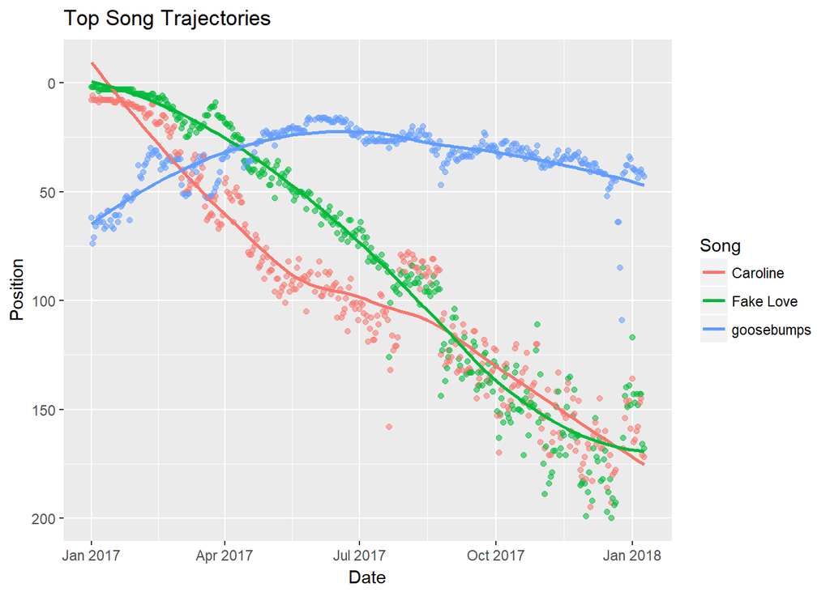

We can follow the same procedure for summer hits. Summer hits are defined here as songs which have been in in the top 10 Spotify most streamed songs between June 1 and August 31, 2017. The songs are labeled by increasing volatility. 21 Savage’s “Bank Account” reappears here as the least volatile song of the summer. Its counterpart, Selena Gomez’s “Fetish”, enters the top after its release at #4 but drops relatively quickly.

```
## # A tibble: 3 x 3
## # Groups:   Artist [3]
##   Artist       Track.Name                volatility
##   <fct>        <fct>                          <dbl>
## 1 Selena Gomez Fetish (feat. Gucci Mane)      66.1
## 2 J Balvin     Mi Gente                       37.2
## 3 21 Savage    Bank Account                    6.44
```

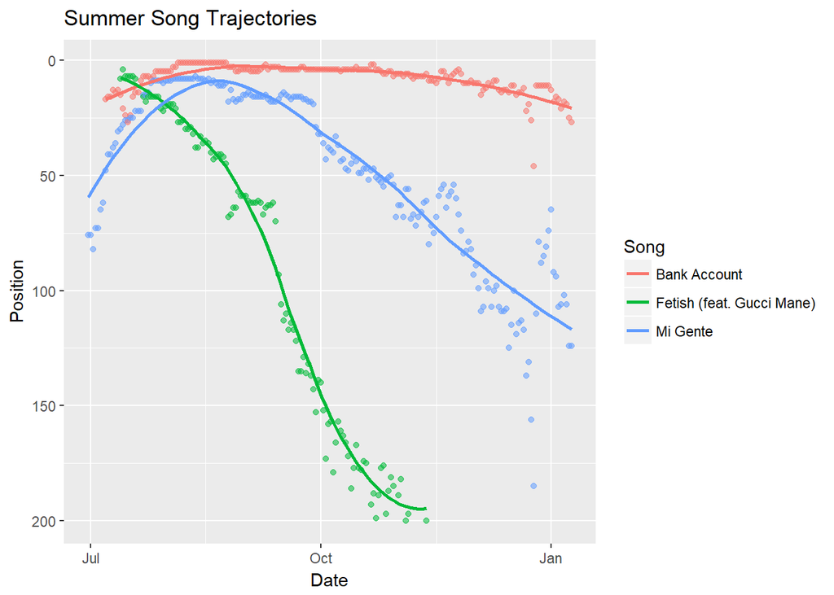

#### DRAKE V KENDRICK

Comparing and contrasting Drake and Kendrick Lamar is particularly interesting for several reasons: first, both artists operate primarily in the same genre; second, their release dates overlapped significantly; and, third, they are two of the most streamed artists on Spotify.

```
## # A tibble: 2 x 5
##   Artist         mean_position mean_streams max_streams occurrences
##   <fct>                  <dbl>        <dbl>       <dbl>       <int>
## 1 Drake                   98.0       389677     2828304        3210
## 2 Kendrick Lamar          60.6       619420     4068152        1879
```

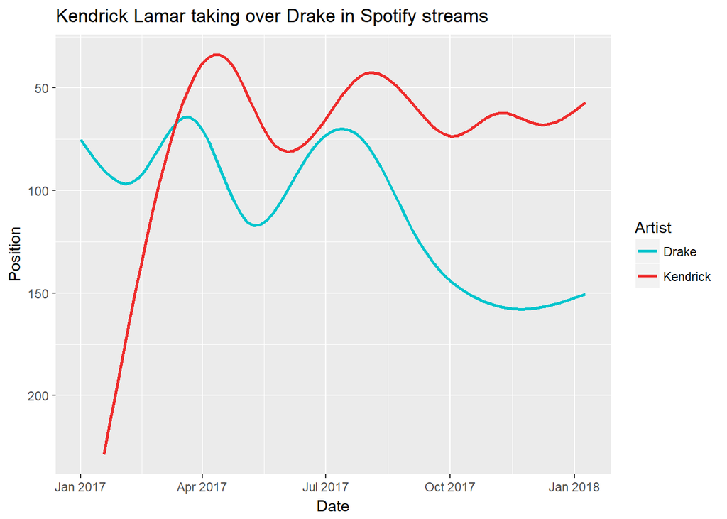

Indeed, this single has proven remarkable popular over time. Drake’s standout track from “More Life”, “Passionfruit”, has by contrast been steadily decreasing in popularity since April.

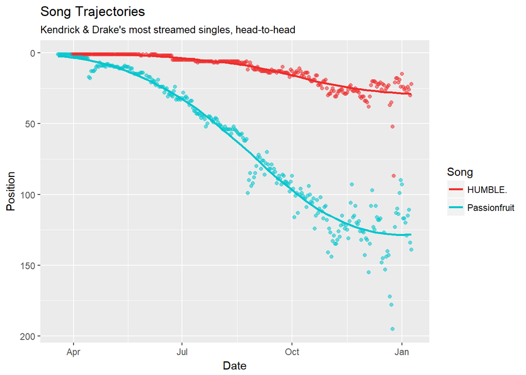